# Risk Factor Analysis

## Outcome Variable

**Outcome Variable:** stunted

## Predictor Variables

**Intervention Variable:** mage

**Adjustment Set:**

unadjusted

## Stratifying Variables

The analysis was stratified on these variable(s):

- agecat
- studyid
- country

## Data Summary

| agecat | studyid | country | mage | stunted | n_cell | n |
| --- | --- | --- | --- | --- | --- | --- |
| Birth | ki0047075b-MAL-ED | BANGLADESH | <20 | 0 | 27 | 257 |
| Birth | ki0047075b-MAL-ED | BANGLADESH | <20 | 1 | 9 | 257 |
| Birth | ki0047075b-MAL-ED | BANGLADESH | [20-25) | 0 | 70 | 257 |
| Birth | ki0047075b-MAL-ED | BANGLADESH | [20-25) | 1 | 14 | 257 |
| Birth | ki0047075b-MAL-ED | BANGLADESH | [25-30) | 0 | 77 | 257 |
| Birth | ki0047075b-MAL-ED | BANGLADESH | [25-30) | 1 | 15 | 257 |
| Birth | ki0047075b-MAL-ED | BANGLADESH | >=30 | 0 | 36 | 257 |
| Birth | ki0047075b-MAL-ED | BANGLADESH | >=30 | 1 | 9 | 257 |
| 6 months | ki0047075b-MAL-ED | BANGLADESH | <20 | 0 | 29 | 241 |
| 6 months | ki0047075b-MAL-ED | BANGLADESH | <20 | 1 | 6 | 241 |
| 6 months | ki0047075b-MAL-ED | BANGLADESH | [20-25) | 0 | 59 | 241 |
| 6 months | ki0047075b-MAL-ED | BANGLADESH | [20-25) | 1 | 19 | 241 |
| 6 months | ki0047075b-MAL-ED | BANGLADESH | [25-30) | 0 | 77 | 241 |
| 6 months | ki0047075b-MAL-ED | BANGLADESH | [25-30) | 1 | 10 | 241 |
| 6 months | ki0047075b-MAL-ED | BANGLADESH | >=30 | 0 | 31 | 241 |
| 6 months | ki0047075b-MAL-ED | BANGLADESH | >=30 | 1 | 10 | 241 |
| 24 months | ki0047075b-MAL-ED | BANGLADESH | <20 | 0 | 13 | 212 |
| 24 months | ki0047075b-MAL-ED | BANGLADESH | <20 | 1 | 16 | 212 |
| 24 months | ki0047075b-MAL-ED | BANGLADESH | [20-25) | 0 | 36 | 212 |
| 24 months | ki0047075b-MAL-ED | BANGLADESH | [20-25) | 1 | 28 | 212 |
| 24 months | ki0047075b-MAL-ED | BANGLADESH | [25-30) | 0 | 48 | 212 |
| 24 months | ki0047075b-MAL-ED | BANGLADESH | [25-30) | 1 | 34 | 212 |
| 24 months | ki0047075b-MAL-ED | BANGLADESH | >=30 | 0 | 17 | 212 |
| 24 months | ki0047075b-MAL-ED | BANGLADESH | >=30 | 1 | 20 | 212 |
| Birth | ki0047075b-MAL-ED | BRAZIL | <20 | 0 | 32 | 191 |
| Birth | ki0047075b-MAL-ED | BRAZIL | <20 | 1 | 2 | 191 |
| Birth | ki0047075b-MAL-ED | BRAZIL | [20-25) | 0 | 56 | 191 |
| Birth | ki0047075b-MAL-ED | BRAZIL | [20-25) | 1 | 7 | 191 |
| Birth | ki0047075b-MAL-ED | BRAZIL | [25-30) | 0 | 45 | 191 |
| Birth | ki0047075b-MAL-ED | BRAZIL | [25-30) | 1 | 9 | 191 |

[output cut: 508 more lines]

The following strata were considered:

- agecat: 24 months, studyid: ki0047075b-MAL-ED, country: BANGLADESH
- agecat: 24 months, studyid: ki0047075b-MAL-ED, country: BRAZIL
- agecat: 24 months, studyid: ki0047075b-MAL-ED, country: INDIA
- agecat: 24 months, studyid: ki0047075b-MAL-ED, country: NEPAL
- agecat: 24 months, studyid: ki0047075b-MAL-ED, country: PERU
- agecat: 24 months, studyid: ki0047075b-MAL-ED, country: SOUTH AFRICA
- agecat: 24 months, studyid: ki0047075b-MAL-ED, country: TANZANIA, UNITED REPUBLIC OF
- agecat: 24 months, studyid: ki1000108-CMC-V-BCS-2002, country: INDIA
- agecat: 24 months, studyid: ki1000108-IRC, country: INDIA
- agecat: 24 months, studyid: ki1017093-NIH-Birth, country: BANGLADESH
- agecat: 24 months, studyid: ki1017093b-PROVIDE, country: BANGLADESH
- agecat: 24 months, studyid: ki1017093c-NIH-Crypto, country: BANGLADESH
- agecat: 24 months, studyid: ki1066203-TanzaniaChild2, country: TANZANIA, UNITED REPUBLIC OF
- agecat: 24 months, studyid: ki1101329-Keneba, country: GAMBIA
- agecat: 24 months, studyid: ki1113344-GMS-Nepal, country: NEPAL
- agecat: 24 months, studyid: ki1119695-PROBIT, country: BELARUS
- agecat: 24 months, studyid: ki1126311-ZVITAMBO, country: ZIMBABWE
- agecat: 24 months, studyid: ki1135781-COHORTS, country: GUATEMALA
- agecat: 24 months, studyid: ki1135781-COHORTS, country: INDIA
- agecat: 24 months, studyid: ki1135781-COHORTS, country: PHILIPPINES
- agecat: 24 months, studyid: ki1148112-LCNI-5, country: MALAWI
- agecat: 24 months, studyid: kiGH5241-JiVitA-3, country: BANGLADESH
- agecat: 6 months, studyid: ki0047075b-MAL-ED, country: BANGLADESH
- agecat: 6 months, studyid: ki0047075b-MAL-ED, country: BRAZIL
- agecat: 6 months, studyid: ki0047075b-MAL-ED, country: INDIA
- agecat: 6 months, studyid: ki0047075b-MAL-ED, country: NEPAL
- agecat: 6 months, studyid: ki0047075b-MAL-ED, country: PERU
- agecat: 6 months, studyid: ki0047075b-MAL-ED, country: SOUTH AFRICA
- agecat: 6 months, studyid: ki0047075b-MAL-ED, country: TANZANIA, UNITED REPUBLIC OF
- agecat: 6 months, studyid: ki1000108-CMC-V-BCS-2002, country: INDIA
- agecat: 6 months, studyid: ki1000108-IRC, country: INDIA
- agecat: 6 months, studyid: ki1000109-EE, country: PAKISTAN
- agecat: 6 months, studyid: ki1000304b-SAS-CompFeed, country: INDIA
- agecat: 6 months, studyid: ki1000304b-SAS-FoodSuppl, country: INDIA
- agecat: 6 months, studyid: ki1017093-NIH-Birth, country: BANGLADESH
- agecat: 6 months, studyid: ki1017093b-PROVIDE, country: BANGLADESH
- agecat: 6 months, studyid: ki1017093c-NIH-Crypto, country: BANGLADESH
- agecat: 6 months, studyid: ki1066203-TanzaniaChild2, country: TANZANIA, UNITED REPUBLIC OF
- agecat: 6 months, studyid: ki1101329-Keneba, country: GAMBIA
- agecat: 6 months, studyid: ki1112895-Guatemala BSC, country: GUATEMALA
- agecat: 6 months, studyid: ki1113344-GMS-Nepal, country: NEPAL
- agecat: 6 months, studyid: ki1119695-PROBIT, country: BELARUS
- agecat: 6 months, studyid: ki1126311-ZVITAMBO, country: ZIMBABWE
- agecat: 6 months, studyid: ki1135781-COHORTS, country: GUATEMALA
- agecat: 6 months, studyid: ki1135781-COHORTS, country: INDIA
- agecat: 6 months, studyid: ki1135781-COHORTS, country: PHILIPPINES
- agecat: 6 months, studyid: ki1148112-LCNI-5, country: MALAWI
- agecat: 6 months, studyid: kiGH5241-JiVitA-3, country: BANGLADESH
- agecat: Birth, studyid: ki0047075b-MAL-ED, country: BANGLADESH
- agecat: Birth, studyid: ki0047075b-MAL-ED, country: BRAZIL
- agecat: Birth, studyid: ki0047075b-MAL-ED, country: INDIA
- agecat: Birth, studyid: ki0047075b-MAL-ED, country: NEPAL
- agecat: Birth, studyid: ki0047075b-MAL-ED, country: PERU
- agecat: Birth, studyid: ki0047075b-MAL-ED, country: SOUTH AFRICA
- agecat: Birth, studyid: ki0047075b-MAL-ED, country: TANZANIA, UNITED REPUBLIC OF
- agecat: Birth, studyid: ki1000108-CMC-V-BCS-2002, country: INDIA
- agecat: Birth, studyid: ki1000108-IRC, country: INDIA
- agecat: Birth, studyid: ki1000109-EE, country: PAKISTAN
- agecat: Birth, studyid: ki1000304b-SAS-CompFeed, country: INDIA
- agecat: Birth, studyid: ki1017093-NIH-Birth, country: BANGLADESH
- agecat: Birth, studyid: ki1017093c-NIH-Crypto, country: BANGLADESH
- agecat: Birth, studyid: ki1101329-Keneba, country: GAMBIA
- agecat: Birth, studyid: ki1119695-PROBIT, country: BELARUS
- agecat: Birth, studyid: ki1126311-ZVITAMBO, country: ZIMBABWE
- agecat: Birth, studyid: ki1135781-COHORTS, country: GUATEMALA
- agecat: Birth, studyid: ki1135781-COHORTS, country: INDIA
- agecat: Birth, studyid: ki1135781-COHORTS, country: PHILIPPINES
- agecat: Birth, studyid: kiGH5241-JiVitA-3, country: BANGLADESH

### Dropped Strata

Some strata were dropped due to rare outcomes:

- agecat: Birth, studyid: ki0047075b-MAL-ED, country: BRAZIL
- agecat: 6 months, studyid: ki0047075b-MAL-ED, country: BRAZIL
- agecat: 24 months, studyid: ki0047075b-MAL-ED, country: BRAZIL
- agecat: Birth, studyid: ki0047075b-MAL-ED, country: INDIA
- agecat: 6 months, studyid: ki0047075b-MAL-ED, country: INDIA
- agecat: 24 months, studyid: ki0047075b-MAL-ED, country: INDIA
- agecat: 6 months, studyid: ki0047075b-MAL-ED, country: NEPAL
- agecat: 24 months, studyid: ki0047075b-MAL-ED, country: NEPAL
- agecat: Birth, studyid: ki0047075b-MAL-ED, country: NEPAL
- agecat: Birth, studyid: ki0047075b-MAL-ED, country: PERU
- agecat: Birth, studyid: ki0047075b-MAL-ED, country: SOUTH AFRICA
- agecat: Birth, studyid: ki0047075b-MAL-ED, country: TANZANIA, UNITED REPUBLIC OF
- agecat: 6 months, studyid: ki0047075b-MAL-ED, country: TANZANIA, UNITED REPUBLIC OF
- agecat: 24 months, studyid: ki0047075b-MAL-ED, country: TANZANIA, UNITED REPUBLIC OF
- agecat: Birth, studyid: ki1000108-CMC-V-BCS-2002, country: INDIA
- agecat: Birth, studyid: ki1000108-IRC, country: INDIA
- agecat: 6 months, studyid: ki1000109-EE, country: PAKISTAN
- agecat: Birth, studyid: ki1000109-EE, country: PAKISTAN
- agecat: Birth, studyid: ki1000304b-SAS-CompFeed, country: INDIA
- agecat: Birth, studyid: ki1017093-NIH-Birth, country: BANGLADESH
- agecat: Birth, studyid: ki1017093c-NIH-Crypto, country: BANGLADESH
- agecat: 24 months, studyid: ki1066203-TanzaniaChild2, country: TANZANIA, UNITED REPUBLIC OF
- agecat: Birth, studyid: ki1119695-PROBIT, country: BELARUS

## Methods Detail

We’re interested in the causal parameters $E[Y_a]$ for all values of $a \in \mathcal{A}$. These parameters represent the mean outcome if, possibly contrary to fact, we intervened to set all units to have $A=a$. Under the randomization and positivity assumptions, these are identified by the statistical parameters $\psi_a=E_W[E_{Y|A,W}(Y|A=a,W)]$. In addition, we’re interested in the mean of $Y$, $E[Y]$ under no intervention (the observed mean). We will estimate these parameters by using SuperLearner to fit the relevant likelihood factors – $E_{Y|A,W}(Y|A=a,W)$ and $p(A=a|W)$, and then updating our likelihood fit using a joint TMLE.

For unadjusted analyses ($W=\{\}$), initial likelihoods were estimated using Lrnr_glm to estimate the simple $E(Y|A)$ and Lrnr_mean to estimate $p(A)$. For adjusted analyses, a small library containing Lrnr_glmnet, Lrnr_xgboost, and Lrnr_mean was used.

Having estimated these parameters, we will then use the delta method to estimate relative risks and attributable risks relative to a prespecified baseline level of $A$.

# Results Detail

## Results Plots

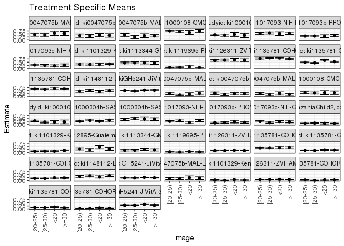

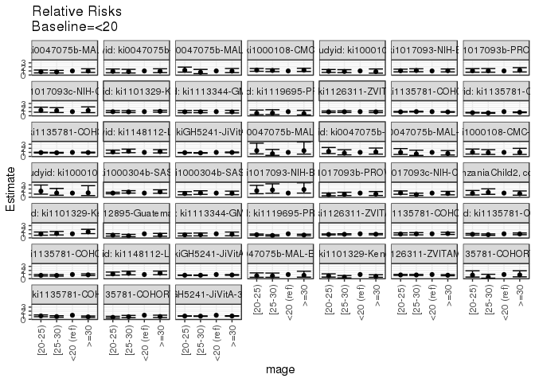

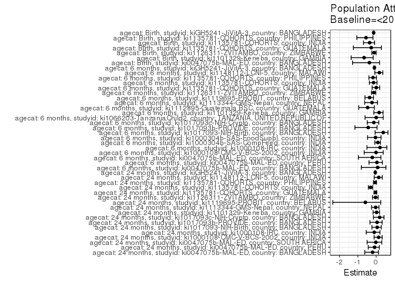

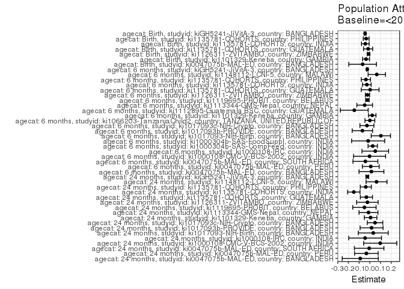

## Results Table

### Parameter: TSM

| agecat | studyid | country | intervention_level | baseline_level | estimate | ci_lower | ci_upper |
| --- | --- | --- | --- | --- | --- | --- | --- |
| Birth | ki0047075b-MAL-ED | BANGLADESH | <20 | NA | 0.2500000 | 0.1082758 | 0.3917242 |
| Birth | ki0047075b-MAL-ED | BANGLADESH | [20-25) | NA | 0.1666667 | 0.0868141 | 0.2465192 |
| Birth | ki0047075b-MAL-ED | BANGLADESH | [25-30) | NA | 0.1630435 | 0.0874118 | 0.2386752 |
| Birth | ki0047075b-MAL-ED | BANGLADESH | >=30 | NA | 0.2000000 | 0.0829023 | 0.3170977 |
| Birth | ki1101329-Keneba | GAMBIA | <20 | NA | 0.0882353 | 0.0521888 | 0.1242818 |
| Birth | ki1101329-Keneba | GAMBIA | [20-25) | NA | 0.0575342 | 0.0336375 | 0.0814310 |
| Birth | ki1101329-Keneba | GAMBIA | [25-30) | NA | 0.0323529 | 0.0135396 | 0.0511662 |
| Birth | ki1101329-Keneba | GAMBIA | >=30 | NA | 0.0484950 | 0.0312726 | 0.0657173 |
| Birth | ki1126311-ZVITAMBO | ZIMBABWE | <20 | NA | 0.1150000 | 0.1016687 | 0.1283313 |
| Birth | ki1126311-ZVITAMBO | ZIMBABWE | [20-25) | NA | 0.1030220 | 0.0952145 | 0.1108294 |
| Birth | ki1126311-ZVITAMBO | ZIMBABWE | [25-30) | NA | 0.1022661 | 0.0921434 | 0.1123889 |
| Birth | ki1126311-ZVITAMBO | ZIMBABWE | >=30 | NA | 0.0950947 | 0.0831678 | 0.1070215 |
| Birth | ki1135781-COHORTS | GUATEMALA | <20 | NA | 0.0743802 | 0.0276007 | 0.1211596 |
| Birth | ki1135781-COHORTS | GUATEMALA | [20-25) | NA | 0.0633484 | 0.0312145 | 0.0954823 |
| Birth | ki1135781-COHORTS | GUATEMALA | [25-30) | NA | 0.0271739 | 0.0036674 | 0.0506804 |
| Birth | ki1135781-COHORTS | GUATEMALA | >=30 | NA | 0.0674847 | 0.0402373 | 0.0947320 |
| Birth | ki1135781-COHORTS | INDIA | <20 | NA | 0.1603261 | 0.1228350 | 0.1978171 |
| Birth | ki1135781-COHORTS | INDIA | [20-25) | NA | 0.1331689 | 0.1166327 | 0.1497052 |
| Birth | ki1135781-COHORTS | INDIA | [25-30) | NA | 0.1084724 | 0.0930292 | 0.1239156 |
| Birth | ki1135781-COHORTS | INDIA | >=30 | NA | 0.0976864 | 0.0806509 | 0.1147219 |
| Birth | ki1135781-COHORTS | PHILIPPINES | <20 | NA | 0.0952381 | 0.0656412 | 0.1248350 |
| Birth | ki1135781-COHORTS | PHILIPPINES | [20-25) | NA | 0.0455487 | 0.0323981 | 0.0586993 |
| Birth | ki1135781-COHORTS | PHILIPPINES | [25-30) | NA | 0.0608187 | 0.0447962 | 0.0768412 |
| Birth | ki1135781-COHORTS | PHILIPPINES | >=30 | NA | 0.0646298 | 0.0481078 | 0.0811519 |
| Birth | kiGH5241-JiVitA-3 | BANGLADESH | <20 | NA | 0.3674118 | 0.3562918 | 0.3785317 |
| Birth | kiGH5241-JiVitA-3 | BANGLADESH | [20-25) | NA | 0.2933182 | 0.2806701 | 0.3059664 |
| Birth | kiGH5241-JiVitA-3 | BANGLADESH | [25-30) | NA | 0.2839799 | 0.2668847 | 0.3010750 |
| Birth | kiGH5241-JiVitA-3 | BANGLADESH | >=30 | NA | 0.2981701 | 0.2753380 | 0.3210021 |
| 6 months | ki0047075b-MAL-ED | BANGLADESH | <20 | NA | 0.1714286 | 0.0463095 | 0.2965477 |
| 6 months | ki0047075b-MAL-ED | BANGLADESH | [20-25) | NA | 0.2435897 | 0.1481318 | 0.3390476 |

[output cut: 150 more lines]

### Parameter: E(Y)

| agecat | studyid | country | intervention_level | baseline_level | estimate | ci_lower | ci_upper |
| --- | --- | --- | --- | --- | --- | --- | --- |
| Birth | ki0047075b-MAL-ED | BANGLADESH | NA | NA | 0.1828794 | 0.1355257 | 0.2302330 |
| Birth | ki1101329-Keneba | GAMBIA | NA | NA | 0.0532122 | 0.0420018 | 0.0644226 |
| Birth | ki1126311-ZVITAMBO | ZIMBABWE | NA | NA | 0.1034083 | 0.0983260 | 0.1084905 |
| Birth | ki1135781-COHORTS | GUATEMALA | NA | NA | 0.0586854 | 0.0428942 | 0.0744767 |
| Birth | ki1135781-COHORTS | INDIA | NA | NA | 0.1183457 | 0.1091247 | 0.1275667 |
| Birth | ki1135781-COHORTS | PHILIPPINES | NA | NA | 0.0613115 | 0.0527962 | 0.0698268 |
| Birth | kiGH5241-JiVitA-3 | BANGLADESH | NA | NA | 0.3231138 | 0.3154608 | 0.3307668 |
| 6 months | ki0047075b-MAL-ED | BANGLADESH | NA | NA | 0.1867220 | 0.1374205 | 0.2360234 |
| 6 months | ki0047075b-MAL-ED | PERU | NA | NA | 0.2197802 | 0.1705687 | 0.2689917 |
| 6 months | ki0047075b-MAL-ED | SOUTH AFRICA | NA | NA | 0.1968504 | 0.1478551 | 0.2458457 |
| 6 months | ki1000108-CMC-V-BCS-2002 | INDIA | NA | NA | 0.3008130 | 0.2539566 | 0.3476694 |
| 6 months | ki1000108-IRC | INDIA | NA | NA | 0.2457002 | 0.2038248 | 0.2875757 |
| 6 months | ki1000304b-SAS-CompFeed | INDIA | NA | NA | 0.2844311 | 0.2666491 | 0.3022132 |
| 6 months | ki1000304b-SAS-FoodSuppl | INDIA | NA | NA | 0.4289474 | 0.3791199 | 0.4787748 |
| 6 months | ki1017093-NIH-Birth | BANGLADESH | NA | NA | 0.2672897 | 0.2297549 | 0.3048246 |
| 6 months | ki1017093b-PROVIDE | BANGLADESH | NA | NA | 0.1612350 | 0.1313580 | 0.1911120 |
| 6 months | ki1017093c-NIH-Crypto | BANGLADESH | NA | NA | 0.2097902 | 0.1799252 | 0.2396552 |
| 6 months | ki1066203-TanzaniaChild2 | TANZANIA, UNITED REPUBLIC OF | NA | NA | 0.0964215 | 0.0835208 | 0.1093221 |
| 6 months | ki1101329-Keneba | GAMBIA | NA | NA | 0.1408654 | 0.1259115 | 0.1558193 |
| 6 months | ki1112895-Guatemala BSC | GUATEMALA | NA | NA | 0.3115942 | 0.2568550 | 0.3663334 |
| 6 months | ki1113344-GMS-Nepal | NEPAL | NA | NA | 0.2113677 | 0.1776128 | 0.2451225 |
| 6 months | ki1119695-PROBIT | BELARUS | NA | NA | 0.0626864 | 0.0488489 | 0.0765239 |
| 6 months | ki1126311-ZVITAMBO | ZIMBABWE | NA | NA | 0.1660628 | 0.1580467 | 0.1740789 |
| 6 months | ki1135781-COHORTS | GUATEMALA | NA | NA | 0.4099896 | 0.3788775 | 0.4411017 |
| 6 months | ki1135781-COHORTS | INDIA | NA | NA | 0.1959625 | 0.1848518 | 0.2070732 |
| 6 months | ki1135781-COHORTS | PHILIPPINES | NA | NA | 0.2112260 | 0.1958496 | 0.2266024 |
| 6 months | ki1148112-LCNI-5 | MALAWI | NA | NA | 0.3736921 | 0.3370052 | 0.4103790 |
| 6 months | kiGH5241-JiVitA-3 | BANGLADESH | NA | NA | 0.2514133 | 0.2432880 | 0.2595385 |
| 24 months | ki0047075b-MAL-ED | BANGLADESH | NA | NA | 0.4622642 | 0.3949918 | 0.5295365 |
| 24 months | ki0047075b-MAL-ED | PERU | NA | NA | 0.3681592 | 0.3013164 | 0.4350020 |
| 24 months | ki0047075b-MAL-ED | SOUTH AFRICA | NA | NA | 0.3529412 | 0.2921001 | 0.4137823 |
| 24 months | ki1000108-CMC-V-BCS-2002 | INDIA | NA | NA | 0.7150538 | 0.6691221 | 0.7609854 |
| 24 months | ki1000108-IRC | INDIA | NA | NA | 0.4156479 | 0.3678270 | 0.4634689 |
| 24 months | ki1017093-NIH-Birth | BANGLADESH | NA | NA | 0.5550351 | 0.5078433 | 0.6022269 |
| 24 months | ki1017093b-PROVIDE | BANGLADESH | NA | NA | 0.3292894 | 0.2909105 | 0.3676684 |
| 24 months | ki1017093c-NIH-Crypto | BANGLADESH | NA | NA | 0.2568093 | 0.2190047 | 0.2946140 |
| 24 months | ki1101329-Keneba | GAMBIA | NA | NA | 0.3348891 | 0.3125397 | 0.3572386 |
| 24 months | ki1113344-GMS-Nepal | NEPAL | NA | NA | 0.4468938 | 0.4032281 | 0.4905594 |
| 24 months | ki1119695-PROBIT | BELARUS | NA | NA | 0.0852540 | 0.0554439 | 0.1150642 |
| 24 months | ki1126311-ZVITAMBO | ZIMBABWE | NA | NA | 0.6535088 | 0.6097853 | 0.6972322 |
| 24 months | ki1135781-COHORTS | GUATEMALA | NA | NA | 0.7919400 | 0.7675726 | 0.8163075 |
| 24 months | ki1135781-COHORTS | INDIA | NA | NA | 0.4944520 | 0.4783291 | 0.5105749 |
| 24 months | ki1135781-COHORTS | PHILIPPINES | NA | NA | 0.6167689 | 0.5974942 | 0.6360437 |
| 24 months | ki1148112-LCNI-5 | MALAWI | NA | NA | 0.4505263 | 0.4057351 | 0.4953175 |
| 24 months | kiGH5241-JiVitA-3 | BANGLADESH | NA | NA | 0.4909007 | 0.4777498 | 0.5040515 |

### Parameter: RR

| agecat | studyid | country | intervention_level | baseline_level | estimate | ci_lower | ci_upper |
| --- | --- | --- | --- | --- | --- | --- | --- |
| Birth | ki0047075b-MAL-ED | BANGLADESH | <20 | <20 | 1.0000000 | 1.0000000 | 1.0000000 |
| Birth | ki0047075b-MAL-ED | BANGLADESH | [20-25) | <20 | 0.6666667 | 0.3173635 | 1.4004269 |
| Birth | ki0047075b-MAL-ED | BANGLADESH | [25-30) | <20 | 0.6521739 | 0.3135047 | 1.3566966 |
| Birth | ki0047075b-MAL-ED | BANGLADESH | >=30 | <20 | 0.8000000 | 0.3541237 | 1.8072783 |
| Birth | ki1101329-Keneba | GAMBIA | <20 | <20 | 1.0000000 | 1.0000000 | 1.0000000 |
| Birth | ki1101329-Keneba | GAMBIA | [20-25) | <20 | 0.6520548 | 0.3641409 | 1.1676124 |
| Birth | ki1101329-Keneba | GAMBIA | [25-30) | <20 | 0.3666667 | 0.1801504 | 0.7462898 |
| Birth | ki1101329-Keneba | GAMBIA | >=30 | <20 | 0.5496098 | 0.3198649 | 0.9443704 |
| Birth | ki1126311-ZVITAMBO | ZIMBABWE | <20 | <20 | 1.0000000 | 1.0000000 | 1.0000000 |
| Birth | ki1126311-ZVITAMBO | ZIMBABWE | [20-25) | <20 | 0.8958433 | 0.7799793 | 1.0289187 |
| Birth | ki1126311-ZVITAMBO | ZIMBABWE | [25-30) | <20 | 0.8892707 | 0.7635410 | 1.0357038 |
| Birth | ki1126311-ZVITAMBO | ZIMBABWE | >=30 | <20 | 0.8269102 | 0.6970849 | 0.9809141 |
| Birth | ki1135781-COHORTS | GUATEMALA | <20 | <20 | 1.0000000 | 1.0000000 | 1.0000000 |
| Birth | ki1135781-COHORTS | GUATEMALA | [20-25) | <20 | 0.8516843 | 0.3796392 | 1.9106722 |
| Birth | ki1135781-COHORTS | GUATEMALA | [25-30) | <20 | 0.3653382 | 0.1253763 | 1.0645708 |
| Birth | ki1135781-COHORTS | GUATEMALA | >=30 | <20 | 0.9072938 | 0.4297030 | 1.9156999 |
| Birth | ki1135781-COHORTS | INDIA | <20 | <20 | 1.0000000 | 1.0000000 | 1.0000000 |
| Birth | ki1135781-COHORTS | INDIA | [20-25) | <20 | 0.8306130 | 0.6373995 | 1.0823949 |
| Birth | ki1135781-COHORTS | INDIA | [25-30) | <20 | 0.6765736 | 0.5145375 | 0.8896374 |
| Birth | ki1135781-COHORTS | INDIA | >=30 | <20 | 0.6092981 | 0.4551371 | 0.8156754 |
| Birth | ki1135781-COHORTS | PHILIPPINES | <20 | <20 | 1.0000000 | 1.0000000 | 1.0000000 |
| Birth | ki1135781-COHORTS | PHILIPPINES | [20-25) | <20 | 0.4782609 | 0.3129275 | 0.7309472 |
| Birth | ki1135781-COHORTS | PHILIPPINES | [25-30) | <20 | 0.6385965 | 0.4249052 | 0.9597565 |
| Birth | ki1135781-COHORTS | PHILIPPINES | >=30 | <20 | 0.6786134 | 0.4537963 | 1.0148081 |
| Birth | kiGH5241-JiVitA-3 | BANGLADESH | <20 | <20 | 1.0000000 | 1.0000000 | 1.0000000 |
| Birth | kiGH5241-JiVitA-3 | BANGLADESH | [20-25) | <20 | 0.7983366 | 0.7590931 | 0.8396088 |
| Birth | kiGH5241-JiVitA-3 | BANGLADESH | [25-30) | <20 | 0.7729199 | 0.7238438 | 0.8253234 |
| Birth | kiGH5241-JiVitA-3 | BANGLADESH | >=30 | <20 | 0.8115420 | 0.7481138 | 0.8803480 |
| 6 months | ki0047075b-MAL-ED | BANGLADESH | <20 | <20 | 1.0000000 | 1.0000000 | 1.0000000 |
| 6 months | ki0047075b-MAL-ED | BANGLADESH | [20-25) | <20 | 1.4209402 | 0.6205843 | 3.2534998 |

[output cut: 150 more lines]

### Parameter: PAR

| agecat | studyid | country | intervention_level | baseline_level | estimate | ci_lower | ci_upper |
| --- | --- | --- | --- | --- | --- | --- | --- |
| Birth | ki0047075b-MAL-ED | BANGLADESH | <20 | NA | -0.0671206 | -0.1963529 | 0.0621117 |
| Birth | ki1101329-Keneba | GAMBIA | <20 | NA | -0.0350231 | -0.0670179 | -0.0030283 |
| Birth | ki1126311-ZVITAMBO | ZIMBABWE | <20 | NA | -0.0115917 | -0.0237098 | 0.0005263 |
| Birth | ki1135781-COHORTS | GUATEMALA | <20 | NA | -0.0156947 | -0.0583106 | 0.0269212 |
| Birth | ki1135781-COHORTS | INDIA | <20 | NA | -0.0419804 | -0.0776343 | -0.0063265 |
| Birth | ki1135781-COHORTS | PHILIPPINES | <20 | NA | -0.0339266 | -0.0609703 | -0.0068830 |
| Birth | kiGH5241-JiVitA-3 | BANGLADESH | <20 | NA | -0.0442979 | -0.0523579 | -0.0362380 |
| 6 months | ki0047075b-MAL-ED | BANGLADESH | <20 | NA | 0.0152934 | -0.1010611 | 0.1316480 |
| 6 months | ki0047075b-MAL-ED | PERU | <20 | NA | 0.0092539 | -0.0692250 | 0.0877328 |
| 6 months | ki0047075b-MAL-ED | SOUTH AFRICA | <20 | NA | -0.0412448 | -0.1576463 | 0.0751566 |
| 6 months | ki1000108-CMC-V-BCS-2002 | INDIA | <20 | NA | -0.0022173 | -0.1520126 | 0.1475780 |
| 6 months | ki1000108-IRC | INDIA | <20 | NA | 0.0512558 | -0.0734230 | 0.1759346 |
| 6 months | ki1000304b-SAS-CompFeed | INDIA | <20 | NA | 0.0271212 | -0.0164127 | 0.0706551 |
| 6 months | ki1000304b-SAS-FoodSuppl | INDIA | <20 | NA | -0.0154971 | -0.1700753 | 0.1390811 |
| 6 months | ki1017093-NIH-Birth | BANGLADESH | <20 | NA | 0.1033553 | 0.0134420 | 0.1932685 |
| 6 months | ki1017093b-PROVIDE | BANGLADESH | <20 | NA | -0.0695342 | -0.1647094 | 0.0256410 |
| 6 months | ki1017093c-NIH-Crypto | BANGLADESH | <20 | NA | -0.0268510 | -0.0920640 | 0.0383619 |
| 6 months | ki1066203-TanzaniaChild2 | TANZANIA, UNITED REPUBLIC OF | <20 | NA | 0.0005311 | -0.0454844 | 0.0465465 |
| 6 months | ki1101329-Keneba | GAMBIA | <20 | NA | 0.0228098 | -0.0122372 | 0.0578568 |
| 6 months | ki1112895-Guatemala BSC | GUATEMALA | <20 | NA | -0.1449275 | -0.2747724 | -0.0150826 |
| 6 months | ki1113344-GMS-Nepal | NEPAL | <20 | NA | -0.0478916 | -0.1210831 | 0.0252999 |
| 6 months | ki1119695-PROBIT | BELARUS | <20 | NA | -0.0224988 | -0.0386076 | -0.0063900 |
| 6 months | ki1126311-ZVITAMBO | ZIMBABWE | <20 | NA | -0.0218833 | -0.0415714 | -0.0021951 |
| 6 months | ki1135781-COHORTS | GUATEMALA | <20 | NA | 0.0032099 | -0.0798606 | 0.0862805 |
| 6 months | ki1135781-COHORTS | INDIA | <20 | NA | -0.0277572 | -0.0683762 | 0.0128619 |
| 6 months | ki1135781-COHORTS | PHILIPPINES | <20 | NA | -0.0365081 | -0.0797649 | 0.0067487 |
| 6 months | ki1148112-LCNI-5 | MALAWI | <20 | NA | 0.0652809 | -0.0157240 | 0.1462857 |
| 6 months | kiGH5241-JiVitA-3 | BANGLADESH | <20 | NA | -0.0238555 | -0.0310962 | -0.0166149 |
| 24 months | ki0047075b-MAL-ED | BANGLADESH | <20 | NA | -0.0894600 | -0.2580924 | 0.0791725 |
| 24 months | ki0047075b-MAL-ED | PERU | <20 | NA | -0.0318408 | -0.1418181 | 0.0781365 |
| 24 months | ki0047075b-MAL-ED | SOUTH AFRICA | <20 | NA | -0.0060332 | -0.1438861 | 0.1318197 |
| 24 months | ki1000108-CMC-V-BCS-2002 | INDIA | <20 | NA | 0.0974067 | -0.0574265 | 0.2522399 |
| 24 months | ki1000108-IRC | INDIA | <20 | NA | -0.0438115 | -0.1969732 | 0.1093501 |
| 24 months | ki1017093-NIH-Birth | BANGLADESH | <20 | NA | 0.0323079 | -0.1075497 | 0.1721654 |
| 24 months | ki1017093b-PROVIDE | BANGLADESH | <20 | NA | 0.0167894 | -0.0905660 | 0.1241448 |
| 24 months | ki1017093c-NIH-Crypto | BANGLADESH | <20 | NA | 0.0488885 | -0.0234909 | 0.1212680 |
| 24 months | ki1101329-Keneba | GAMBIA | <20 | NA | 0.0077002 | -0.0507072 | 0.0661076 |
| 24 months | ki1113344-GMS-Nepal | NEPAL | <20 | NA | -0.0122899 | -0.1007737 | 0.0761939 |
| 24 months | ki1119695-PROBIT | BELARUS | <20 | NA | -0.0502473 | -0.1593658 | 0.0588712 |
| 24 months | ki1126311-ZVITAMBO | ZIMBABWE | <20 | NA | -0.0225476 | -0.1229916 | 0.0778965 |
| 24 months | ki1135781-COHORTS | GUATEMALA | <20 | NA | -0.0315894 | -0.0881458 | 0.0249670 |
| 24 months | ki1135781-COHORTS | INDIA | <20 | NA | -0.1492727 | -0.2071586 | -0.0913869 |
| 24 months | ki1135781-COHORTS | PHILIPPINES | <20 | NA | -0.0373407 | -0.0887019 | 0.0140205 |
| 24 months | ki1148112-LCNI-5 | MALAWI | <20 | NA | 0.0630263 | -0.0348516 | 0.1609043 |
| 24 months | kiGH5241-JiVitA-3 | BANGLADESH | <20 | NA | -0.0232368 | -0.0364755 | -0.0099982 |

### Parameter: PAF

| agecat | studyid | country | intervention_level | baseline_level | estimate | ci_lower | ci_upper |
| --- | --- | --- | --- | --- | --- | --- | --- |
| Birth | ki0047075b-MAL-ED | BANGLADESH | <20 | NA | -0.3670213 | -1.2881552 | 0.1832953 |
| Birth | ki1101329-Keneba | GAMBIA | <20 | NA | -0.6581779 | -1.3640946 | -0.1630474 |
| Birth | ki1126311-ZVITAMBO | ZIMBABWE | <20 | NA | -0.1120968 | -0.2355729 | -0.0009601 |
| Birth | ki1135781-COHORTS | GUATEMALA | <20 | NA | -0.2674380 | -1.2424553 | 0.2836427 |
| Birth | ki1135781-COHORTS | INDIA | <20 | NA | -0.3547267 | -0.6911131 | -0.0852523 |
| Birth | ki1135781-COHORTS | PHILIPPINES | <20 | NA | -0.5533486 | -1.0563133 | -0.1734068 |
| Birth | kiGH5241-JiVitA-3 | BANGLADESH | <20 | NA | -0.1370970 | -0.1625293 | -0.1122212 |
| 6 months | ki0047075b-MAL-ED | BANGLADESH | <20 | NA | 0.0819048 | -0.8094888 | 0.5341784 |
| 6 months | ki0047075b-MAL-ED | PERU | <20 | NA | 0.0421053 | -0.3905477 | 0.3401432 |
| 6 months | ki0047075b-MAL-ED | SOUTH AFRICA | <20 | NA | -0.2095238 | -0.9706004 | 0.2576131 |
| 6 months | ki1000108-CMC-V-BCS-2002 | INDIA | <20 | NA | -0.0073710 | -0.6514740 | 0.3855208 |
| 6 months | ki1000108-IRC | INDIA | <20 | NA | 0.2086111 | -0.5015179 | 0.5828912 |
| 6 months | ki1000304b-SAS-CompFeed | INDIA | <20 | NA | 0.0953524 | -0.0704947 | 0.2355056 |
| 6 months | ki1000304b-SAS-FoodSuppl | INDIA | <20 | NA | -0.0361282 | -0.4671254 | 0.2682551 |
| 6 months | ki1017093-NIH-Birth | BANGLADESH | <20 | NA | 0.3866789 | -0.0572188 | 0.6441959 |
| 6 months | ki1017093b-PROVIDE | BANGLADESH | <20 | NA | -0.4312602 | -1.1582073 | 0.0508299 |
| 6 months | ki1017093c-NIH-Crypto | BANGLADESH | <20 | NA | -0.1279898 | -0.4856086 | 0.1435422 |
| 6 months | ki1066203-TanzaniaChild2 | TANZANIA, UNITED REPUBLIC OF | <20 | NA | 0.0055077 | -0.6069725 | 0.3845477 |
| 6 months | ki1101329-Keneba | GAMBIA | <20 | NA | 0.1619264 | -0.1271642 | 0.3768722 |
| 6 months | ki1112895-Guatemala BSC | GUATEMALA | <20 | NA | -0.4651163 | -0.9505969 | -0.1004661 |
| 6 months | ki1113344-GMS-Nepal | NEPAL | <20 | NA | -0.2265795 | -0.6258181 | 0.0746214 |
| 6 months | ki1119695-PROBIT | BELARUS | <20 | NA | -0.3589106 | -0.6111167 | -0.1461852 |
| 6 months | ki1126311-ZVITAMBO | ZIMBABWE | <20 | NA | -0.1317771 | -0.2566637 | -0.0193017 |
| 6 months | ki1135781-COHORTS | GUATEMALA | <20 | NA | 0.0078293 | -0.2169592 | 0.1910964 |
| 6 months | ki1135781-COHORTS | INDIA | <20 | NA | -0.1416455 | -0.3688520 | 0.0478486 |
| 6 months | ki1135781-COHORTS | PHILIPPINES | <20 | NA | -0.1728392 | -0.3964240 | 0.0149468 |
| 6 months | ki1148112-LCNI-5 | MALAWI | <20 | NA | 0.1746916 | -0.0731963 | 0.3653221 |
| 6 months | kiGH5241-JiVitA-3 | BANGLADESH | <20 | NA | -0.0948858 | -0.1240312 | -0.0664961 |
| 24 months | ki0047075b-MAL-ED | BANGLADESH | <20 | NA | -0.1935257 | -0.6217645 | 0.1216335 |
| 24 months | ki0047075b-MAL-ED | PERU | <20 | NA | -0.0864865 | -0.4304562 | 0.1747717 |
| 24 months | ki0047075b-MAL-ED | SOUTH AFRICA | <20 | NA | -0.0170940 | -0.4932718 | 0.3072391 |
| 24 months | ki1000108-CMC-V-BCS-2002 | INDIA | <20 | NA | 0.1362229 | -0.1106257 | 0.3282067 |
| 24 months | ki1000108-IRC | INDIA | <20 | NA | -0.1054054 | -0.5429054 | 0.2080389 |
| 24 months | ki1017093-NIH-Birth | BANGLADESH | <20 | NA | 0.0582087 | -0.2307843 | 0.2793450 |
| 24 months | ki1017093b-PROVIDE | BANGLADESH | <20 | NA | 0.0509868 | -0.3380332 | 0.3269031 |
| 24 months | ki1017093c-NIH-Crypto | BANGLADESH | <20 | NA | 0.1903690 | -0.1458825 | 0.4279498 |
| 24 months | ki1101329-Keneba | GAMBIA | <20 | NA | 0.0229933 | -0.1679510 | 0.1827208 |
| 24 months | ki1113344-GMS-Nepal | NEPAL | <20 | NA | -0.0275007 | -0.2458763 | 0.1525983 |
| 24 months | ki1119695-PROBIT | BELARUS | <20 | NA | -0.5893836 | -2.3656546 | 0.2494357 |
| 24 months | ki1126311-ZVITAMBO | ZIMBABWE | <20 | NA | -0.0345023 | -0.2002653 | 0.1083679 |
| 24 months | ki1135781-COHORTS | GUATEMALA | <20 | NA | -0.0398886 | -0.1138911 | 0.0291974 |
| 24 months | ki1135781-COHORTS | INDIA | <20 | NA | -0.3018953 | -0.4250897 | -0.1893507 |
| 24 months | ki1135781-COHORTS | PHILIPPINES | <20 | NA | -0.0605424 | -0.1472298 | 0.0195947 |
| 24 months | ki1148112-LCNI-5 | MALAWI | <20 | NA | 0.1398949 | -0.1074942 | 0.3320228 |
| 24 months | kiGH5241-JiVitA-3 | BANGLADESH | <20 | NA | -0.0473351 | -0.0746833 | -0.0206828 |